# Questão 1 - Prova 2 - Econometria II

Aishameriane Schmidt

2 de novembro de 2017

# Introdução e Interpretação Econômica

A questão solicita que sejam analisadas pelo menos 3 séries temporais (podendo ser macroeconômicas ou financeiras).

A escolha das variáveis é com base no seguinte argumento econômico: se a taxa de juros americana sobe, os ativos dos Estados Unidos ficam mais atraentes para investidores. Então, investidores cujo portfólio envolve títulos brasileiros ficarão atraídos a trocar seus ativos (pois os papéis americanos tem risco menor), de forma que há um aumento da procura por dólares (enquanto que há uma diminuição da procura por reais). Esse movimento cria uma alteração na taxa de câmbio, uma vez que a alta procura pelo dólar gera uma pressão para que seu “preço” suba, causando uma desvalorização cambial. O aumento da taxa de câmbio nominal faz com que fique mais caro importar bens e com isso a cesta de itens ao consumidor fica mais cara, gerando pressão inflacionária.

# Análise descritiva das séries

Carregando os pacotes:

Leitura das séries (as séries do Brasil eu baixei em outro computador e salvei o csv porque sou avessa ao risco e não quero mexer na minha instalação do R antes do final do semestre para instalar o BETS, hehe):

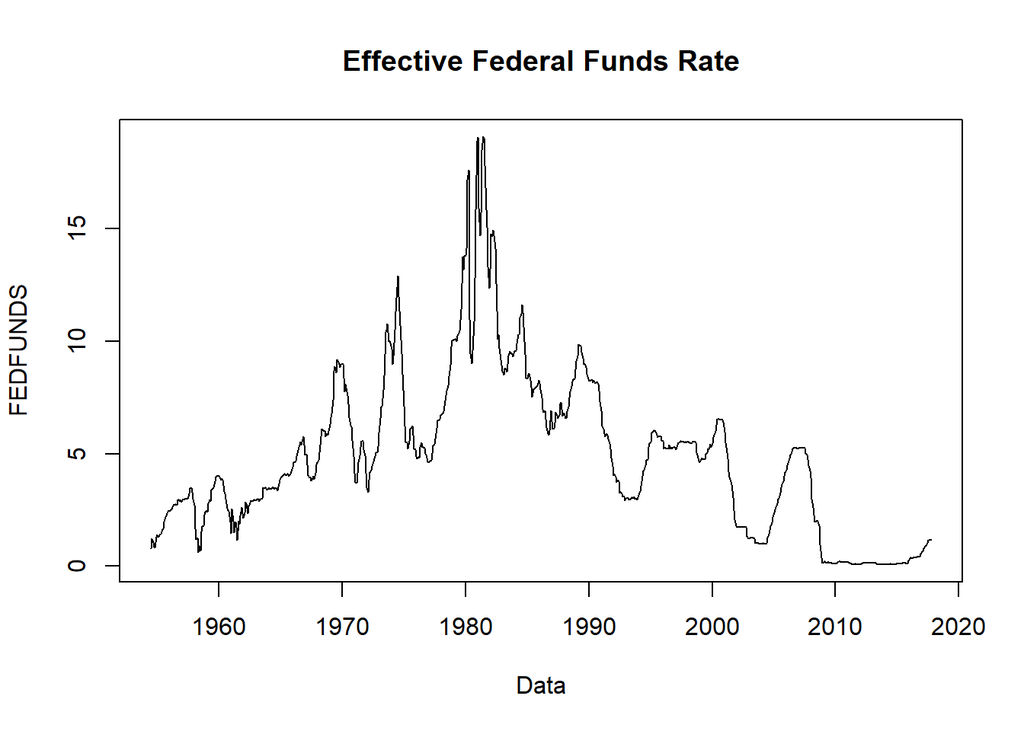

```r
FEDFUNDS <- getSymbols("FEDFUNDS", src = "FRED", auto.assign = FALSE)

# Taxa de juros americana
plot.ts(
  ts(FEDFUNDS,
     start = c(
       as.numeric(format(index(FEDFUNDS)[1],"%Y")),
       as.numeric(format(index(FEDFUNDS)[1],"%m"))
     ),
     frequency = 12
  ), # some backwards conversion to ts from xts
  xlab = "Data",
  ylab = "FEDFUNDS",
  main = "Effective Federal Funds Rate"
)
```

```r
ipca <- read.csv("C:\\Users\\Aishameriane\\Dropbox\\Problema dos pontos\\ipca.csv")
head(ipca)
```

```
##   X    x
## 1 1 6.62
## 2 2 4.62
## 3 3 6.04
## 4 4 5.29
## 5 5 5.70
## 6 6 5.31
```

```r
dolar <- read.csv("C:\\Users\\Aishameriane\\Dropbox\\Problema dos pontos\\dolar.csv")
head(dolar)
```

```
##   X     x
## 1 1 18.72
## 2 2 38.00
## 3 3 42.00
## 4 4 40.00
## 5 5 44.00
## 6 6 44.50
```

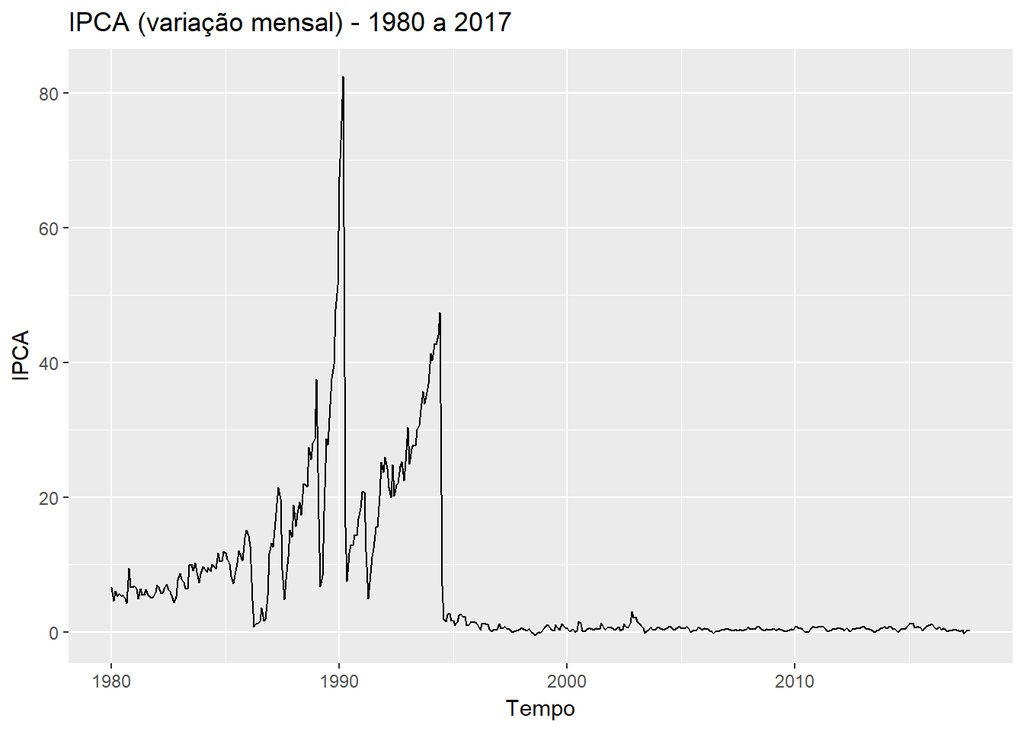

```r
ipca2 <- ts(ipca[,2], start = c(1980,1), end = c(2017, 09), frequency = 12)
autoplot(ipca2, main = "IPCA (variação mensal) - 1980 a 2017", xlab = "Tempo", ylab = "IPCA")
```

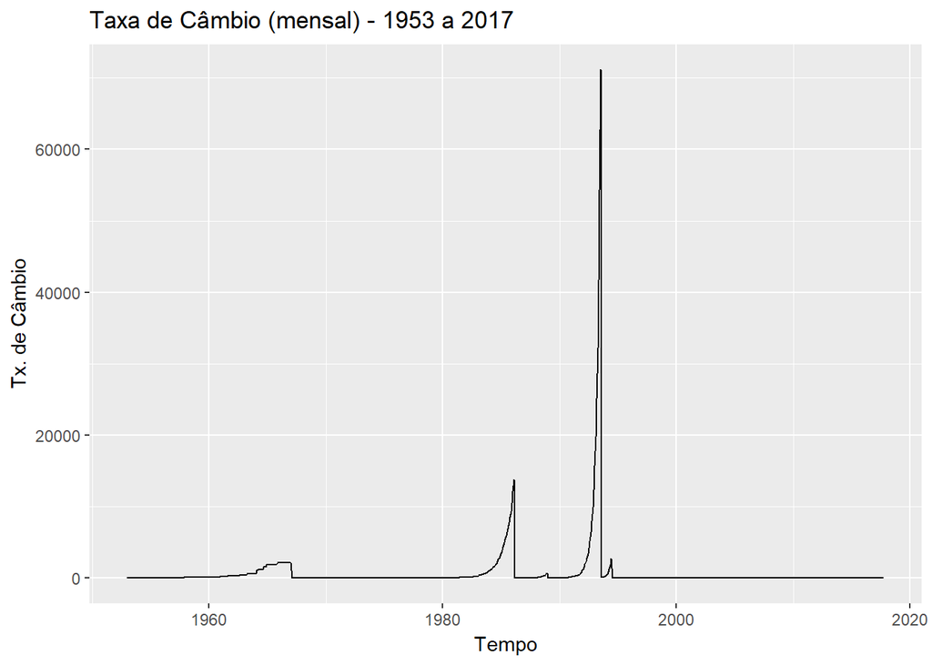

```r
dolar2 <- ts(dolar[,2], start = c(1953,1), end = c(2017, 10), frequency = 12)
autoplot(dolar2, main = "Taxa de Câmbio (mensal) - 1953 a 2017", xlab = "Tempo", ylab = "Tx. de Câmbio")
```

Como a série do IPCA e do dólar sofrem muita variação (principalmente no período de hiperinflação e trocas de moeda no Brasil), optei por cortar as séries (arbitrariamente) no ano 2000.

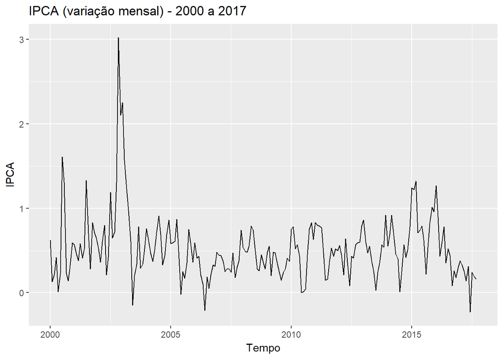

```r
ipca2 <- tail(ipca2, n=213)
autoplot(ipca2, main = "IPCA (variação mensal) - 2000 a 2017", xlab = "Tempo", ylab = "IPCA")
```

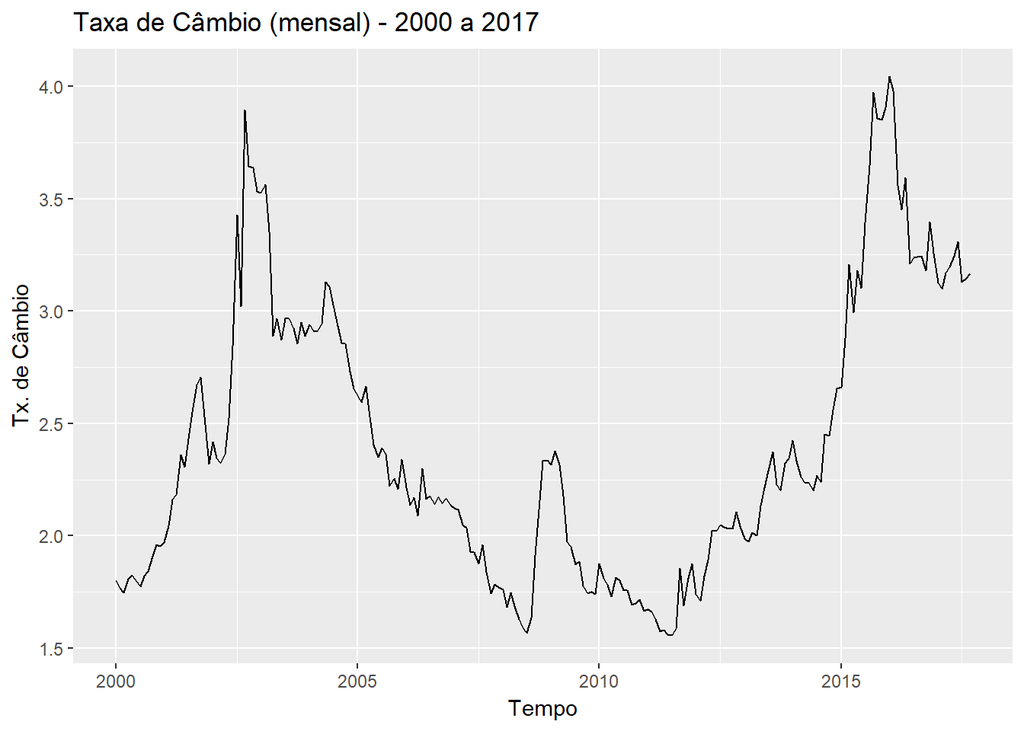

```r
dolar2 <- tail(dolar2, n=214)
dolar2 <- head(dolar2, n=213)
autoplot(dolar2, main = "Taxa de Câmbio (mensal) - 2000 a 2017", xlab = "Tempo", ylab = "Tx. de Câmbio")
```

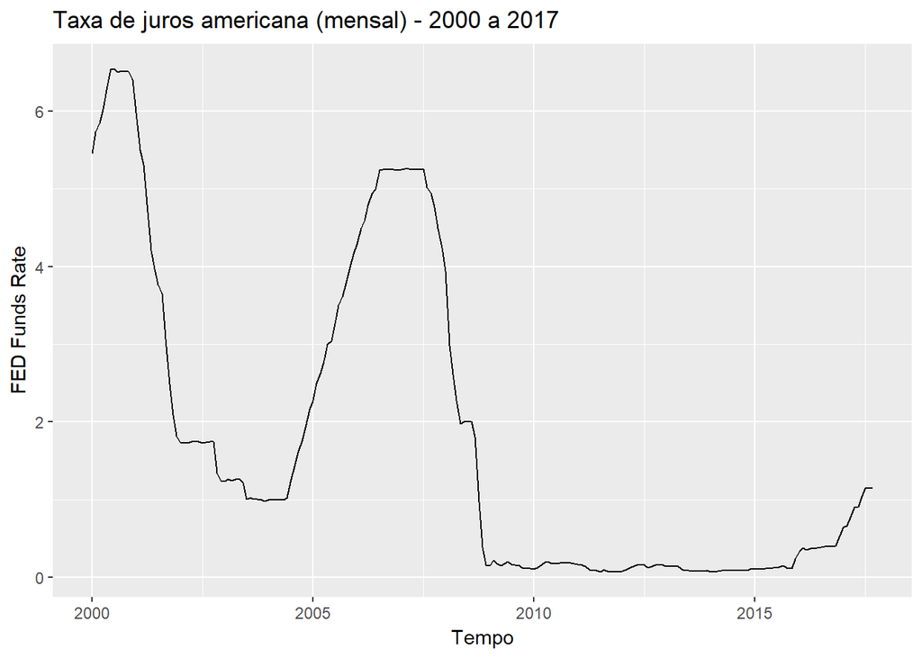

```r
juroseua <- tail(FEDFUNDS, n=214)
juroseua <- head(juroseua, n=213)
juroseua <- ts(juroseua, start = c(2000,1), end = c(2017, 9), frequency = 12)
autoplot(juroseua, main = "Taxa de juros americana (mensal) - 2000 a 2017", xlab = "Tempo", ylab = "FED Funds Rate")
```

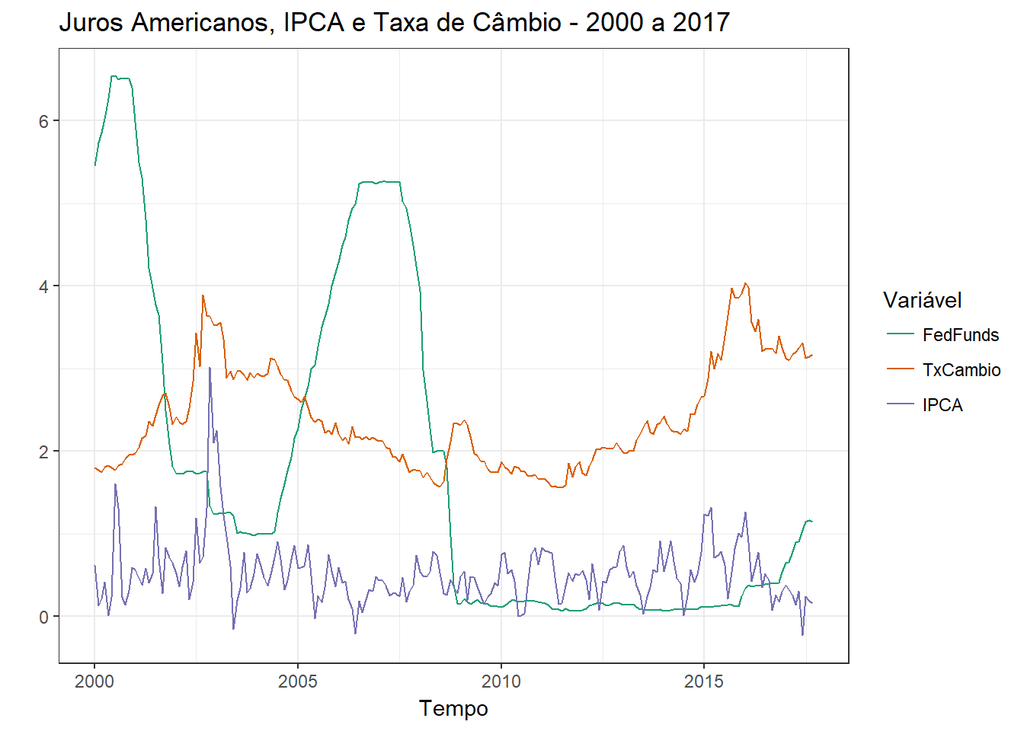

```r
# Monta um dataframe para fazer um gráfico das três séries juntas

datas <- seq.Date(as.Date('2000-01-01'), as.Date('2017-09-01'), by='month')

df <- data.frame(datas, juroseua, dolar2, ipca2)
colnames(df) <- c("Data", "FedFunds", "TxCambio", "IPCA")
df2 <- melt(data = df, id.vars = "Data")

ggplot(df2, aes(Data, value, colour = variable)) +
  geom_line(alpha = 1)+
  labs(title="Juros Americanos, IPCA e Taxa de Câmbio - 2000 a 2017", y = "", x= "Tempo", color = "Variável") +
  scale_colour_brewer(palette = "Dark2") +
  theme_bw()
```

Aparentemente a intuição econômica anterior sobre a taxa de juros americana estar relacionada com a taxa de câmbio faz sentido: os períodos de queda do FedFunds (linha verde) são sucedidos de aumentos na taxa de câmbio (linha laranja). No entanto, a inflação parece ter uma vida própria distinta das duas outras variáveis. Vamos analisar a estacionariedade das séries, procurando por raízes unitárias.

```r
ndiffs(ipca2,test="adf",alpha = 0.1)
```

```
## [1] 0
```

```r
ndiffs(dolar2, test = "adf", alpha = 0.1)
```

```
## [1] 1
```

```r
ndiffs(juroseua, test = "adf", alpha = 0.1)
```

```
## [1] 0
```

Bom, aparentemente apenas a taxa de câmbio é não estacionária, o que vai complicar a minha vida para falar de cointegração.

Pensando em uma estrutura similar à que havia sido proposta anteriormente, pode-se pensar na influência que o mercado financeiro americado tem sobre as variáveis macroeconômicas brasileiras. Um dos índices mais tradicionais do mercado americano é o índice Dow Jones. Assim como a taxa de juros americana, eu esperaria que aumentos no índice (que sinalizam maior retorno aos investidores) afetem a taxa de câmbio brasileira. Como já visto que a taxa de câmbio é $I(1)$, a outra variável que vou utilizar é novamente o IPCA, mas dessa vez não vou pegar a variação. Como no Fred as três variáveis estão disponíveis, vou pegar tudo de lá, exceto o Dow Jones, que para ser mensal tive que baixar a planilha do site.

```r
dowjones <- read.csv("C:\\Users\\Aishameriane\\Dropbox\\Problema dos pontos\\DJIA.csv")
head(dowjones)
```

```
##         DATE     DJIA
## 1 2007-11-01 13200.58
## 2 2007-12-01 13406.99
## 3 2008-01-01 12538.12
## 4 2008-02-01 12419.57
## 5 2008-03-01 12193.88
## 6 2008-04-01 12656.63
```

```r
tail(dowjones)
```

```
##           DATE     DJIA
## 115 2017-05-01 20936.81
## 116 2017-06-01 21317.80
## 117 2017-07-01 21581.25
## 118 2017-08-01 21914.08
## 119 2017-09-01 22173.41
## 120 2017-10-01 23036.24
```

```r
dowjones <- head(dowjones, n=118)
dowjones2 <- ts(dowjones[,2], start = c(2007,11), end = c(2017, 08), frequency = 12)

ipca <- read.csv("C:\\Users\\Aishameriane\\Dropbox\\Problema dos pontos\\BRACPIALLMINMEI.csv")
head(ipca)
```

```
##         DATE BRACPIALLMINMEI
## 1 2007-11-01            87.1
## 2 2007-12-01            87.7
## 3 2008-01-01            88.2
## 4 2008-02-01            88.6
## 5 2008-03-01            89.0
## 6 2008-04-01            89.5
```

```r
tail(ipca)
```

```
##           DATE BRACPIALLMINMEI
## 113 2017-03-01           154.8
## 114 2017-04-01           155.0
## 115 2017-05-01           155.5
## 116 2017-06-01           155.2
## 117 2017-07-01           155.5
## 118 2017-08-01           155.8
```

```r
ipca2 <- ts(ipca[,2], start = c(2007,11), end = c(2017, 08), frequency = 12)

cambio <- read.csv("C:\\Users\\Aishameriane\\Dropbox\\Problema dos pontos\\EXBZUS.csv")
head(cambio)
```

```
##         DATE EXBZUS
## 1 2007-11-01 1.7669
## 2 2007-12-01 1.7852
## 3 2008-01-01 1.7710
## 4 2008-02-01 1.7290
## 5 2008-03-01 1.7090
## 6 2008-04-01 1.6863
```

```r
tail(cambio)
```

```
##           DATE EXBZUS
## 115 2017-05-01 3.2043
## 116 2017-06-01 3.2954
## 117 2017-07-01 3.1994
## 118 2017-08-01 3.1478
## 119 2017-09-01 3.1325
## 120 2017-10-01 3.1846
```

[figure not shown]

```r
cambio  <- head(cambio, n=118)
cambio2 <- ts(cambio[,2], start = c(2007,11), end = c(2017, 08), frequency = 12)

datas <- seq.Date(as.Date('2007-11-01'), as.Date('2017-08-01'), by='month')

df <- data.frame(datas, dowjones2/1000, cambio2*100, ipca2)
colnames(df) <- c("Data", "Dow Jones", "TxCambio", "IPCA")
df2 <- melt(data = df, id.vars = "Data")

ggplot(df2, aes(Data, value, colour = variable)) +
  geom_line(alpha = 1)+
  labs(title="Índ. Dow Jones(/1000), IPCA e Taxa de Câmbio(*100) - 2000 a 2017", y = "", x= "Tempo", color = "Variável") +
  scale_colour_brewer(palette = "Dark2") +
  theme_bw()
```

Agora, vamos verificar a estacionariedade das séries. Foi utilizado o teste de Dikey Fulles aumentado com significância de 5%.

```r
noquote(paste0(c("A variável IPCA é integrada de ordem ", ndiffs(ipca2,test="adf",alpha = 0.05))))
```

```
## [1] A variável IPCA é integrada de ordem
## [2] 1
```

```r
noquote(paste0(c("A variável taxa de câmbio é integrada de ordem ", ndiffs(cambio2, test = "adf", alpha = 0.05))))
```

```
## [1] A variável taxa de câmbio é integrada de ordem
## [2] 1
```

```r
noquote(paste0(c("A série do Índice Dow Jones é integrada de ordem ", ndiffs(dowjones2, test = "adf", alpha = 0.05))))
```

```
## [1] A série do Índice Dow Jones é integrada de ordem
## [2] 1
```

A análise visual das séries é confirmada pelo teste de raiz unitária: de fato as três séries aparentam uma tendência positiva não estacionária.

# Estimando um modelo VAR

Para a seleção do melhor modelo, utilizei a função `VARselect`. Essa função fornece o critério de informação para um número máximo de lags. Como este modelo é macroeconômico, acredito que mais de 4 meses não fazem sentido para as defasagens e por isso trunquei neste valor o lag máximo. Eu cheguei a testa para o lag máximo igual a 10 e a escolha permaneceu em um modelo mais parcimonioso de ordem $2$ (dois dos 4 critérios indicaram que seria 3).

```r
VARselect(df[,c(2,3,4)], lag.max = 4)
```

```
## $selection
## AIC(n)  HQ(n)  SC(n) FPE(n)
##      2      2      2      2
##
## $criteria
##                1          2           3         4
## AIC(n) 0.5197871 -0.0779417 -0.06307576 0.0249672
## HQ(n)  0.6366787  0.1266185  0.22915308 0.4048647
## SC(n)  0.8078080  0.4260949  0.65697647 0.9610351
## FPE(n) 1.6818151  0.9254477  0.94014652 1.0283508
```

Tendo selecionado o número de defasagens igual a 2, vou estimar o modelo VAR utilizando a função de mesmo nome.

```r
MeuVar <- VAR(df[,c(2,3,4)], p = 2, type = "both")
summary(MeuVar)
```

```
##
## VAR Estimation Results:
## =========================
## Endogenous variables: Dow.Jones, TxCambio, IPCA
## Deterministic variables: both
## Sample size: 116
## Log Likelihood: -457.568
## Roots of the characteristic polynomial:
## 0.9168 0.8876 0.8876 0.5355 0.5355 0.03141
## Call:
## VAR(y = df[, c(2, 3, 4)], p = 2, type = "both")
##
##
## Estimation results for equation Dow.Jones:
## ==========================================
## Dow.Jones = Dow.Jones.l1 + TxCambio.l1 + IPCA.l1 + Dow.Jones.l2 + TxCambio.l2 + IPCA.l2 + const + trend
##
##               Estimate Std. Error t value Pr(>|t|)
## Dow.Jones.l1  0.971375   0.106233   9.144 4.11e-15 ***
## TxCambio.l1  -0.009304   0.004702  -1.979   0.0504 .
## IPCA.l1      -0.055525   0.131632  -0.422   0.6740
## Dow.Jones.l2 -0.069212   0.105243  -0.658   0.5122
## TxCambio.l2   0.008472   0.005000   1.694   0.0931 .
## IPCA.l2       0.053042   0.121873   0.435   0.6643
## const         1.029675   1.470090   0.700   0.4852
## trend         0.015631   0.010198   1.533   0.1283
## ---
## Signif. codes:  0 '***' 0.001 '**' 0.01 '*' 0.05 '.' 0.1 ' ' 1
##
##
## Residual standard error: 0.4164 on 108 degrees of freedom
## Multiple R-Squared: 0.9875,  Adjusted R-squared: 0.9867
## F-statistic:  1217 on 7 and 108 DF,  p-value: < 2.2e-16
##
##
## Estimation results for equation TxCambio:
## =========================================
## TxCambio = Dow.Jones.l1 + TxCambio.l1 + IPCA.l1 + Dow.Jones.l2 + TxCambio.l2 + IPCA.l2 + const + trend
##
##              Estimate Std. Error t value Pr(>|t|)
```

[output cut: 36 more lines]

```
## F-statistic: 1.204e+05 on 7 and 108 DF,  p-value: < 2.2e-16
##
##
##
## Covariance matrix of residuals:
##           Dow.Jones TxCambio    IPCA
## Dow.Jones   0.17338  -1.7190 0.00181
## TxCambio   -1.71901  81.0099 0.17672
## IPCA        0.00181   0.1767 0.06044
##
## Correlation matrix of residuals:
##           Dow.Jones TxCambio    IPCA
## Dow.Jones   1.00000 -0.45868 0.01768
## TxCambio   -0.45868  1.00000 0.07987
## IPCA        0.01768  0.07987 1.00000
```

Com relação ao modelo estimado, podemos analisar individualmente cada equação do VAR.

Optei pela inclusão de uma variável para intercepto e uma de tendência, dado que as séries são não estacionárias.

Com relação à equação do índice Dow Jones, vemos que ele tem como coeficiante mais importante o da sua própria defasagem, onde o valor do índice hoje depende diretamente do valor passado (mas não depende do valor em duas defasagens anteriores). Isso corrobora a análise de raiz unitária feita anteriormente. Considerando 10% de significância também são significativos os coeficientes associados à primeira e à segunda defasagens da taxa de câmbio. Isso é condizente com a intuição de que o índice financeiro de fato influencia na taxa de câmbio através da atração dos ativos (o valor do coeficiente da primeira defasagem é segundo, o que sugere uma relação inversa entre as variáveis).

Já a taxa de câmbio se relaciona, a uma significância de 10%, exclusivamente com suas duas defasagens anteriores, contrariando a expectativa de que pudesse sofrer influèncias do Índice Americano.

Finalmente, para a equação do IPCA, encontramos que são significativos a um nível de significância de 10%: as suas duas defasagens, o coeficiente do índice Dow Jones e as variáveis indicando constante e tendência.

Pela matriz de correlação dos resíduos, vê-se uma relação negativa entre a taxa de Câmbio e o Índice Dow Jones, conforme era esperado, mas positiva entre o IPCA e o Índice (embora essa correlação seja muito pequena). Também é positiva e pequena a correlação entre o IPCA e a taxa de câmbio. Eu esperava que a taxa de câmbio fosse o “canal” por onde o Índice DJ afetasse a inflação no Brasil, então esse resultado de certa forma contrariou as expectativas.

# Funções Impulso Resposta e Causalidade de Granger

Para as funções impulso resposta, estou utilizando a função `irf`.

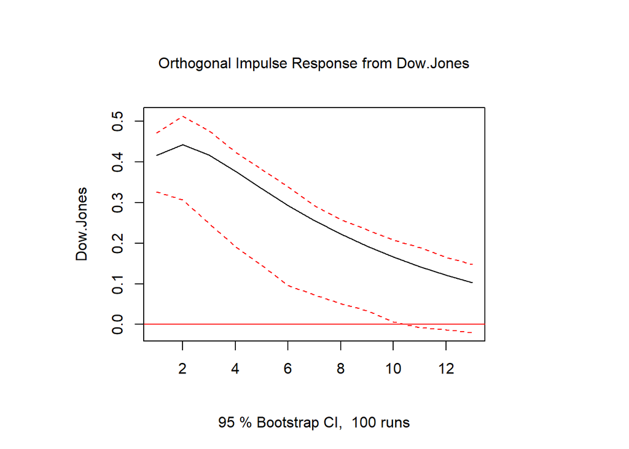

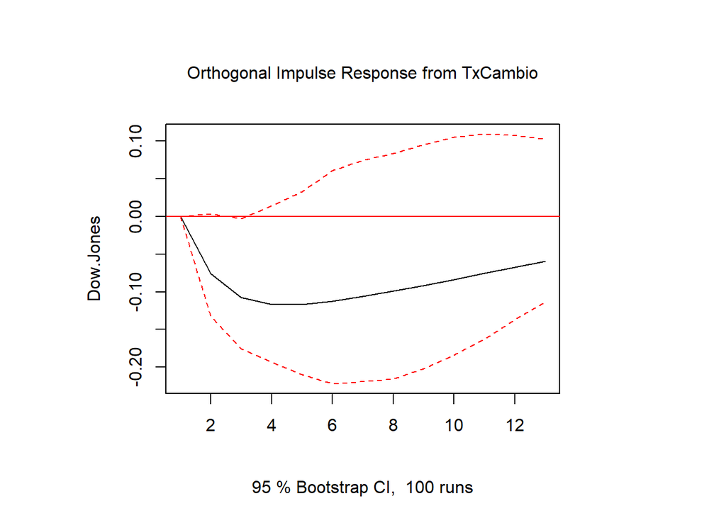

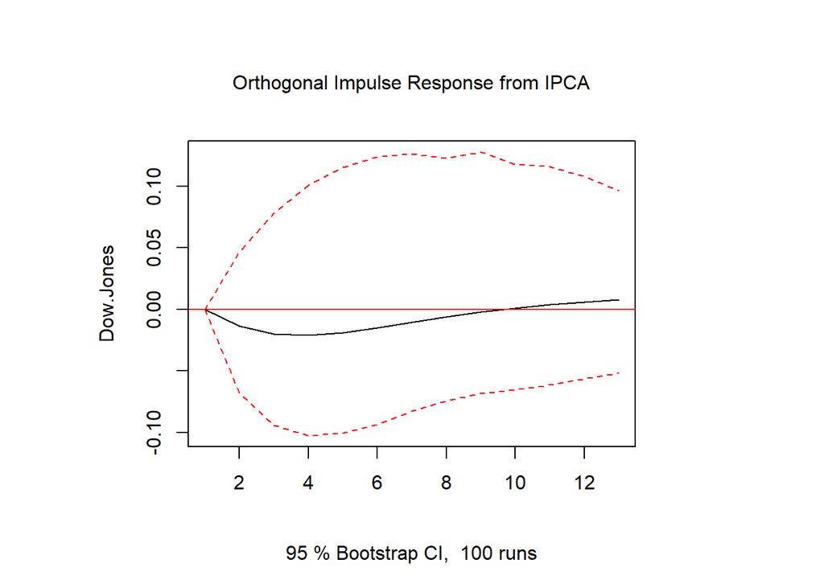

```r
#Função impulso resposta para a variável "Dow Jones"
DJ.IRF <- irf(MeuVar, response = "Dow.Jones", n.ahead = 12, boot = TRUE)
plot(DJ.IRF)
```

A análise da função impulso resposta para a variável Dow Jones sugere que de fato choques na taxa de câmbio afetam negativamente essa variável. Porém, através do IC da função observamos que em 4 meses esse efeito já não é dintinguível do valor zero. Com relação ao IPCA, o IC contém o zero em toda sua extensão.

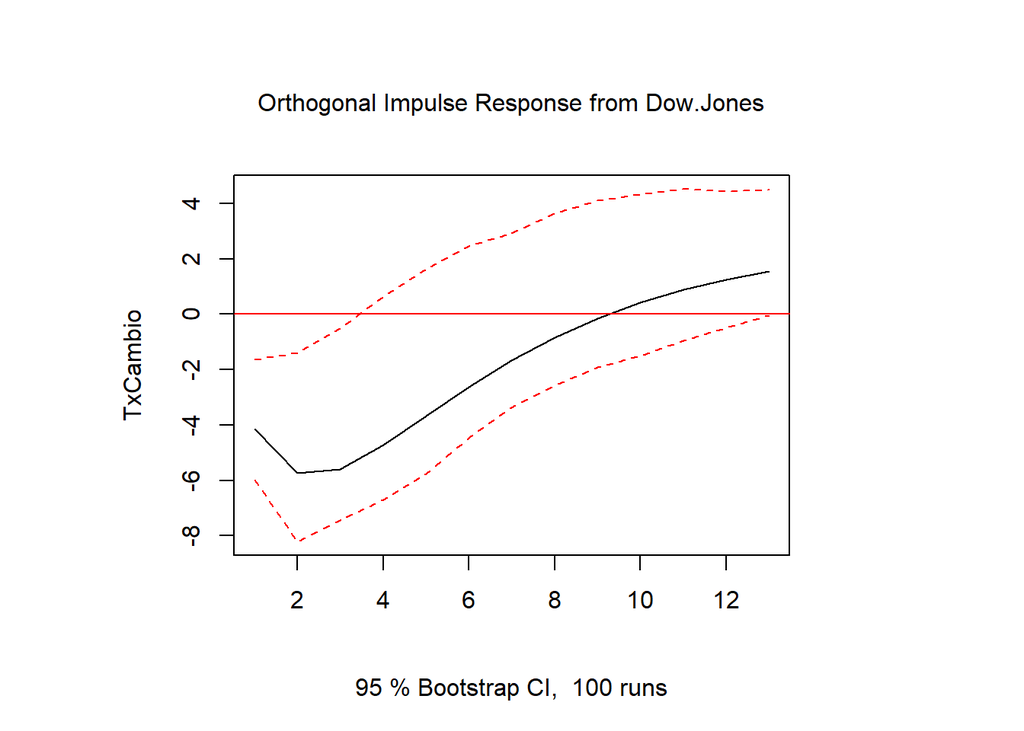

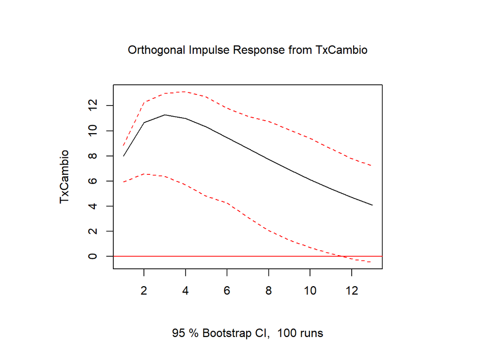

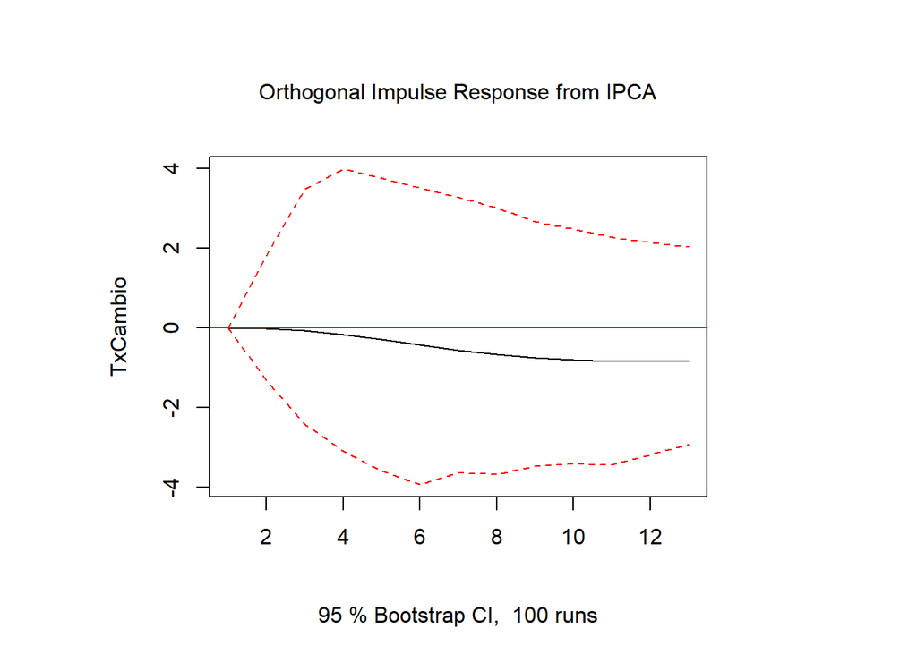

```r
#Função impulso resposta para a variável "cambio"
Cambio.IRF <- irf(MeuVar, response = "TxCambio", n.ahead = 12, boot = TRUE)
plot(Cambio.IRF)
```

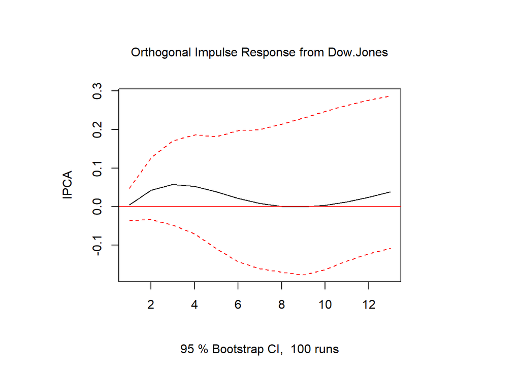

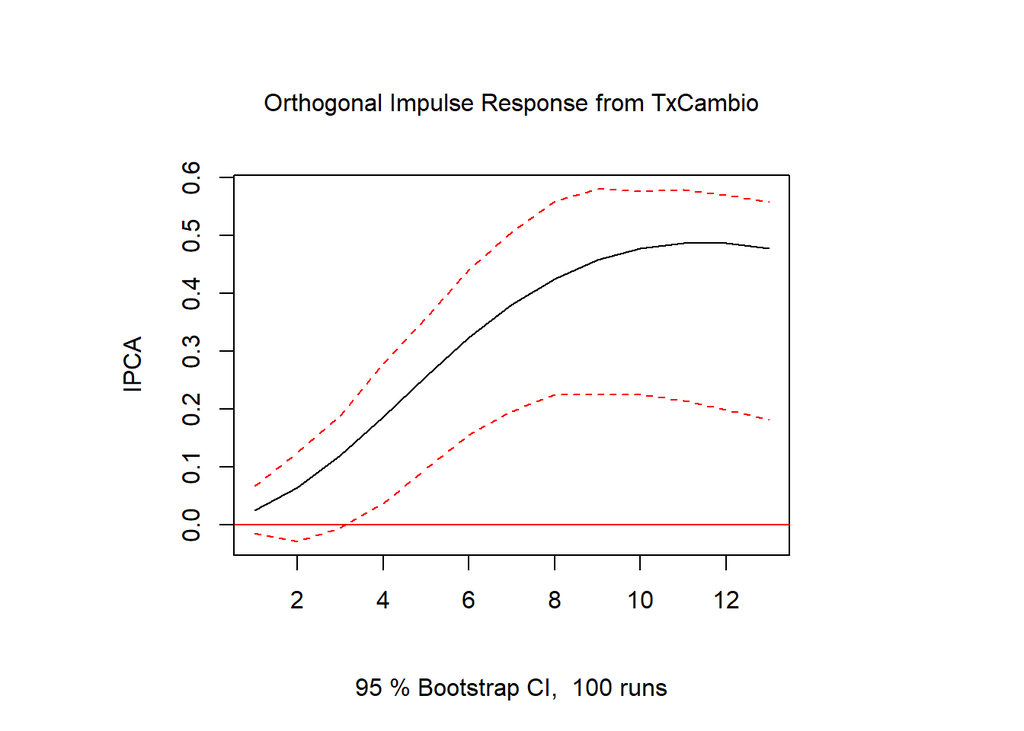

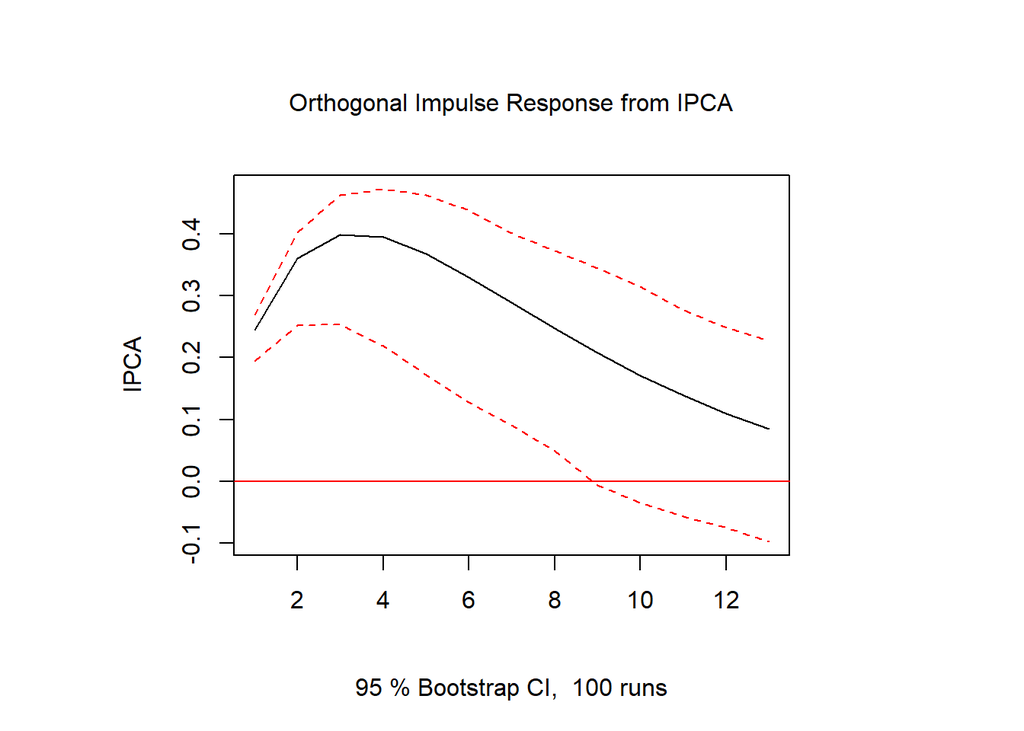

```r
#Função impulso resposta para a variável "IPCA"
IPCA.IRF <- irf(MeuVar, response = "IPCA", n.ahead = 12, boot = TRUE)
plot(IPCA.IRF)
```

Para o IPCA, apesar do Índice Dow Jones aparentar uma relação positiva, essa relação não é estatisticamente diferente de zero. Porém, quando analisamos a FIR para IPCA e Taxa de Câmbio, vemos uma relação positiva: choques positivos na taxa de câmbio farão a inflação aumentar, o que faz sentido, considerando que a cesta de bens do IPCA possivelmente tem muitos produtos importados.

Agora, vamos calcular o teste de causalidade de Granger.

```r
#Causalidade de Granger
causality(MeuVar, cause = "TxCambio")
```

```
## $Granger
##
##  Granger causality H0: TxCambio do not Granger-cause Dow.Jones
##  IPCA
##
## data:  VAR object MeuVar
## F-Test = 6.3356, df1 = 4, df2 = 324, p-value = 6.415e-05
##
##
## $Instant
##
##  H0: No instantaneous causality between: TxCambio and Dow.Jones
##  IPCA
##
## data:  VAR object MeuVar
## Chi-squared = 20.772, df = 2, p-value = 3.086e-05
```

```r
causality(MeuVar, cause = "Dow.Jones")
```

```
## $Granger
##
##  Granger causality H0: Dow.Jones do not Granger-cause TxCambio
##  IPCA
##
## data:  VAR object MeuVar
## F-Test = 2.7009, df1 = 4, df2 = 324, p-value = 0.03066
##
##
## $Instant
##
##  H0: No instantaneous causality between: Dow.Jones and TxCambio
##  IPCA
##
## data:  VAR object MeuVar
## Chi-squared = 20.397, df = 2, p-value = 3.722e-05
```

```r
causality(MeuVar, cause = "IPCA")
```

```
## $Granger
##
##  Granger causality H0: IPCA do not Granger-cause Dow.Jones
##  TxCambio
##
## data:  VAR object MeuVar
## F-Test = 0.10906, df1 = 4, df2 = 324, p-value = 0.9793
##
##
## $Instant
##
##  H0: No instantaneous causality between: IPCA and Dow.Jones
##  TxCambio
##
## data:  VAR object MeuVar
## Chi-squared = 1.1616, df = 2, p-value = 0.5595
```

Para a taxa de câmbio, rejeita-se a hipótese nula de que ela não causa, no sentido de Granger, o índice Dow Jones e o IPCA. O mesmo pode ser dito para o índice Dow Jones e as outras duas variáveis. Por fim, aceita-se a hipótese de não causalidade (no sentido de Granger) do IPCA nas demais variáveis.

# Análise de Cointegração

Para análise de cointegração, será utilizada a função `ca.jo` do pacote `urca`, que faz o teste de Johansen. Escolhi fazer pelo método do traço.

```r
dados <- ts.intersect(dowjones2,ipca2,cambio2)
summary(ca.jo(dados, type = "trace", ecdet = "const", K = 2, spec = "transitory", season = 12))
```

```
##
## ######################
## # Johansen-Procedure #
## ######################
##
## Test type: trace statistic , without linear trend and constant in cointegration
##
## Eigenvalues (lambda):
## [1] 1.743861e-01 1.699878e-01 9.256645e-02 1.110223e-16
##
## Values of teststatistic and critical values of test:
##
##           test 10pct  5pct  1pct
## r <= 2 | 11.27  7.52  9.24 12.97
## r <= 1 | 32.88 17.85 19.96 24.60
## r = 0  | 55.11 32.00 34.91 41.07
##
## Eigenvectors, normalised to first column:
## (These are the cointegration relations)
##
##              dowjones2.l1   ipca2.l1  cambio2.l1  constant
## dowjones2.l1       1.0000     1.0000     1.00000     1.000
## ipca2.l1        -338.3582  -410.1825   -86.58475  -136.994
## cambio2.l1      5727.8087  3240.5839 -2345.15062  4184.671
## constant       14694.5468 16651.2560  1962.22734 -8234.048
##
## Weights W:
## (This is the loading matrix)
##
##              dowjones2.l1      ipca2.l1    cambio2.l1      constant
## dowjones2.d -4.666439e-02 -2.415051e-02 -3.265197e-02  2.152217e-16
## ipca2.d      3.742510e-05 -1.365872e-05  8.228235e-06 -8.563179e-20
## cambio2.d   -1.002318e-06  7.375052e-07  1.514081e-05 -3.139065e-20
```

Analisando as estatísticas de teste e comparando com os valores críticos, conclui-se que para o nível de significância de 1% existem dois vetores de cointegração. Com isso, podemos estimar um modelo VEC (item f).

```r
# Estima modelo VEC
vecm <- ca.jo(dados, type = "trace", ecdet = "const", K = 2, spec = "transitory", season = 12)
vecm.r2 <- cajorls(vecm, r = 2)
print(vecm.r2)
```

```
## $rlm
##
## Call:
## lm(formula = substitute(form1), data = data.mat)
##
## Coefficients:
##                dowjones2.d  ipca2.d     cambio2.d
## ect1           -7.081e-02    2.377e-05  -2.648e-07
## ect2            2.570e+01   -7.061e-03   3.663e-05
## sd1             2.922e+02    2.315e-02   4.374e-02
## sd2             2.893e+02    5.100e-02   3.210e-02
## sd3             4.157e+01    1.024e-01  -3.435e-02
## sd4             1.472e+02   -2.449e-02  -3.900e-03
## sd5             2.582e+02   -1.185e-01   7.251e-03
## sd6             3.081e+02   -2.897e-02  -4.549e-02
## sd7             6.829e+01   -9.434e-02   3.675e-02
## sd8            -8.851e+01   -3.074e-01   5.495e-03
## sd9             1.291e+02   -1.366e-01  -8.628e-03
## sd10           -8.687e+01   -1.881e-01   4.550e-02
## sd11           -2.331e+01    4.497e-02   7.633e-02
## dowjones2.dl1   5.446e-02    9.260e-05   5.458e-06
## ipca2.dl1      -8.648e+01    6.065e-01   2.550e-02
## cambio2.dl1    -6.097e+02    1.225e-01   4.340e-01
##
##
## $beta
##                   ect1     ect2
## dowjones2.l1     1.000   0.0000
## ipca2.l1         0.000   1.0000
## cambio2.l1   17444.915  34.6293
## constant      5476.655 -27.2430
```

```r
summary(vecm.r2$rlm)
```

```
## Response dowjones2.d :
##
## Call:
## lm(formula = dowjones2.d ~ ect1 + ect2 + sd1 + sd2 + sd3 + sd4 +
##     sd5 + sd6 + sd7 + sd8 + sd9 + sd10 + sd11 + dowjones2.dl1 +
##     ipca2.dl1 + cambio2.dl1 - 1, data = data.mat)
##
## Residuals:
##      Min       1Q   Median       3Q      Max
## -1524.82  -172.31    -4.92   242.06  1278.54
##
## Coefficients:
##                 Estimate Std. Error t value Pr(>|t|)
## ect1            -0.07081    0.02070  -3.420 0.000907 ***
## ect2            25.69540    7.21875   3.560 0.000570 ***
## sd1            292.24358  199.34931   1.466 0.145789
## sd2            289.32846  200.12697   1.446 0.151381
## sd3             41.57331  198.14693   0.210 0.834242
## sd4            147.21696  205.11114   0.718 0.474590
## sd5            258.23692  200.31483   1.289 0.200318
## sd6            308.07038  196.45781   1.568 0.120011
## sd7             68.29318  201.29488   0.339 0.735118
## sd8            -88.50658  194.77319  -0.454 0.650520
## sd9            129.05537  197.06464   0.655 0.514043
## sd10           -86.87293  197.17185  -0.441 0.660457
## sd11           -23.30689  199.80410  -0.117 0.907372
## dowjones2.dl1    0.05446    0.10876   0.501 0.617670
## ipca2.dl1      -86.48243  132.64475  -0.652 0.515906
## cambio2.dl1   -609.73947  489.20483  -1.246 0.215533
## ---
## Signif. codes:  0 '***' 0.001 '**' 0.01 '*' 0.05 '.' 0.1 ' ' 1
##
## Residual standard error: 418 on 100 degrees of freedom
## Multiple R-squared:  0.2844, Adjusted R-squared:  0.1699
## F-statistic: 2.484 on 16 and 100 DF,  p-value: 0.003174
##
##
## Response ipca2.d :
##
## Call:
```

[output cut: 54 more lines]

```
## sd6           -4.549e-02  4.279e-02  -1.063   0.2903
## sd7            3.675e-02  4.385e-02   0.838   0.4040
## sd8            5.495e-03  4.243e-02   0.130   0.8972
## sd9           -8.628e-03  4.293e-02  -0.201   0.8411
## sd10           4.550e-02  4.295e-02   1.059   0.2920
## sd11           7.633e-02  4.352e-02   1.754   0.0825 .
## dowjones2.dl1  5.459e-06  2.369e-05   0.230   0.8183
## ipca2.dl1      2.550e-02  2.889e-02   0.883   0.3796
## cambio2.dl1    4.340e-01  1.066e-01   4.073 9.31e-05 ***
## ---
## Signif. codes:  0 '***' 0.001 '**' 0.01 '*' 0.05 '.' 0.1 ' ' 1
##
## Residual standard error: 0.09105 on 100 degrees of freedom
## Multiple R-squared:  0.2853, Adjusted R-squared:  0.1709
## F-statistic: 2.495 on 16 and 100 DF,  p-value: 0.003045
```

A matriz beta nos mostra que com relação à sua primeira componente (primeiro vetor de cointegração), o câmbio e a constante aparecem com valores altos, o mesmo para a segunda componente. Quando olhamos os coeficientes, o coeficiente de ambos vetores é estatisticamente diferente de zero para o Índice Dow Jones enquanto que os coeficientes dos vetores de cointegração são estatisticamente iguais a zero para o câmbio. Quanto ao IPCA, apenas o primeiro vetor tem coeficiente não nulo, considerando 10% de significância.